> **Tip**: Welcome to the Investigate a Dataset project! You will find tips in quoted sections like this to help organize your approach to your investigation. Once you complete this project, remove these **Tip** sections from your report before submission. First things first, you might want to double-click this Markdown cell and change the title so that it reflects your dataset and investigation.

# Project: Investigate a Dataset - [No-show appointments_May_2016]

- Introduction
- Data Wrangling
- Exploratory Data Analysis
- Conclusions

## Introduction

### Dataset Description

This dataset collects information from 100k medical appointments in Brazil and is focused on the question of whether or not patients show up for their appointment. A number of characteristics about the patient areincluded in each row.

1 PatientID - Indicates ID for each patient 2 AppointmentID - Indicates ID for each appointment made 3 ScheduledDay - Tells us on what day the patient set up their appointment. 4 Neighborhood - Indicates the location of the hospital. 5 Scholarship - Indicates whether or not the patient is enrolled in Brasilian welfare program Bolsa Família. 6 SMS_recieved - Indicates message sent to the patient 7 No_show - Indicates if the patients was present for appointment or not. NO (means patient showed up), YES (means patient did not show up) ● Be careful about the encoding of the last column: it says ‘No’ if the patient showed up to their appointment, and ‘Yes’ if they did not show up.

### Question(s) for Analysis

Question 1. What is the total number of patients with scholarship and how many of the patients did not show up for their appointments?

Question 2. Does gender determine if patients show up for appointments or not?

```python
#   plan to use.
import pandas as pd
import numpy as np
import matplotlib.pyplot as plt
import seaborn as sns
% matplotlib inline
```

```python
# Upgrade pandas to use dataframe.explode() function.
!pip install --upgrade pandas==0.25.0
```

## Data Wrangling

```python
# Load your data and print out a few lines. Perform operations to inspect data
#   types and look for instances of missing or possibly errant data.
df_appointments = pd.read_csv('Database_No_show_appointments/noshowappointments-kagglev2-may-2016.csv')
df_appointments.head(2)
```

|  | PatientId | AppointmentID | Gender | ScheduledDay | AppointmentDay | Age | Neighbourhood | Scholarship | Hipertension | Diabetes | Alcoholism | Handcap | SMS_received | No-show |
| --- | --- | --- | --- | --- | --- | --- | --- | --- | --- | --- | --- | --- | --- | --- |
| 0 | 2.987250e+13 | 5642903 | F | 2016-04-29T18:38:08Z | 2016-04-29T00:00:00Z | 62 | JARDIM DA PENHA | 0 | 1 | 0 | 0 | 0 | 0 | No |
| 1 | 5.589978e+14 | 5642503 | M | 2016-04-29T16:08:27Z | 2016-04-29T00:00:00Z | 56 | JARDIM DA PENHA | 0 | 0 | 0 | 0 | 0 | 0 | No |

```python
df_appointments.info()
```

```
<class 'pandas.core.frame.DataFrame'>
RangeIndex: 110527 entries, 0 to 110526
Data columns (total 14 columns):
PatientId         110527 non-null float64
AppointmentID     110527 non-null int64
Gender            110527 non-null object
ScheduledDay      110527 non-null object
AppointmentDay    110527 non-null object
Age               110527 non-null int64
Neighbourhood     110527 non-null object
Scholarship       110527 non-null int64
Hipertension      110527 non-null int64
Diabetes          110527 non-null int64
Alcoholism        110527 non-null int64
Handcap           110527 non-null int64
SMS_received      110527 non-null int64
No-show           110527 non-null object
dtypes: float64(1), int64(8), object(5)
memory usage: 11.8+ MB
```

```python
df_appointments.shape
```

```
(110527, 14)
```

From the data, we have 110527 patients and 14 columns to work with

Go to resource to check isnull value https://stackoverflow.com/questions/60249807/python-isnull-sum-vs-isnull-count

```python
df_appointments.isnull().sum()
```

```
PatientId         0
AppointmentID     0
Gender            0
ScheduledDay      0
AppointmentDay    0
Age               0
Neighbourhood     0
Scholarship       0
Hipertension      0
Diabetes          0
Alcoholism        0
Handcap           0
SMS_received      0
No-show           0
dtype: int64
```

The result shows that we have no missing values in our data set

```python
sum(df_appointments.duplicated())
```

```
0
```

The output shows we have no duplicated value in our datasets

```python
df_appointments.describe()
```

|  | PatientId | AppointmentID | Age | Scholarship | Hipertension | Diabetes | Alcoholism | Handcap | SMS_received |
| --- | --- | --- | --- | --- | --- | --- | --- | --- | --- |
| count | 1.105270e+05 | 1.105270e+05 | 110527.000000 | 110527.000000 | 110527.000000 | 110527.000000 | 110527.000000 | 110527.000000 | 110527.000000 |
| mean | 1.474963e+14 | 5.675305e+06 | 37.088874 | 0.098266 | 0.197246 | 0.071865 | 0.030400 | 0.022248 | 0.321026 |
| std | 2.560949e+14 | 7.129575e+04 | 23.110205 | 0.297675 | 0.397921 | 0.258265 | 0.171686 | 0.161543 | 0.466873 |
| min | 3.921784e+04 | 5.030230e+06 | -1.000000 | 0.000000 | 0.000000 | 0.000000 | 0.000000 | 0.000000 | 0.000000 |
| 25% | 4.172614e+12 | 5.640286e+06 | 18.000000 | 0.000000 | 0.000000 | 0.000000 | 0.000000 | 0.000000 | 0.000000 |
| 50% | 3.173184e+13 | 5.680573e+06 | 37.000000 | 0.000000 | 0.000000 | 0.000000 | 0.000000 | 0.000000 | 0.000000 |
| 75% | 9.439172e+13 | 5.725524e+06 | 55.000000 | 0.000000 | 0.000000 | 0.000000 | 0.000000 | 0.000000 | 1.000000 |
| max | 9.999816e+14 | 5.790484e+06 | 115.000000 | 1.000000 | 1.000000 | 1.000000 | 1.000000 | 4.000000 | 1.000000 |

The data shows that: 1.The mean age is 37 years 2.The minimum age is -1, This is an error which might affect our analysis. Therefore, we need to do some cleaning on the age column

```python
#Identifying the patients with age of -1

age_error = df_appointments.query('Age == "-1"')
age_error
```

|  | PatientId | AppointmentID | Gender | ScheduledDay | AppointmentDay | Age | Neighbourhood | Scholarship | Hipertension | Diabetes | Alcoholism | Handcap | SMS_received | No-show |
| --- | --- | --- | --- | --- | --- | --- | --- | --- | --- | --- | --- | --- | --- | --- |
| 99832 | 4.659432e+14 | 5775010 | F | 2016-06-06T08:58:13Z | 2016-06-06T00:00:00Z | -1 | ROMÃO | 0 | 0 | 0 | 0 | 0 | 0 | No |

### Data Cleaning

To prepare our data for analysis we need to:

1.We need to clean the patient with the age of -1

2.ScheduleDay column needs to be changed to datetime data type

3.AppointmentDay column needs to be changed to datetime data type

4.Hippertension column need to be renamed correctly

5.No-show column need to be renamed to No_show

6.Convert Scholarship datatype from int to bool

```python
# We need to remove the row with patient age of -1 to prevent error in our analysis

df_appointments.drop(index=99832, inplace=True)

#Go to resource to drop row//www.geeksforgeeks.org/drop-rows-from-the-dataframe
```

```python
# Changing datatype from strings to datetime for ScheduledDay column

df_appointments['ScheduledDay'] = pd.to_datetime(df_appointments['ScheduledDay'])
df_appointments['ScheduledDay'] = df_appointments['ScheduledDay'].dt.date
```

```python
# Changing datatype from strings to datetime for AppointmentsDay Column and removing extra characters

df_appointments['AppointmentDay'] = pd.to_datetime(df_appointments['AppointmentDay'])
df_appointments['AppointmentDay'] = df_appointments['AppointmentDay'].dt.date
df_appointments.head(1)
```

|  | PatientId | AppointmentID | Gender | ScheduledDay | AppointmentDay | Age | Neighbourhood | Scholarship | Hipertension | Diabetes | Alcoholism | Handcap | SMS_received | No-show |
| --- | --- | --- | --- | --- | --- | --- | --- | --- | --- | --- | --- | --- | --- | --- |
| 0 | 2.987250e+13 | 5642903 | F | 2016-04-29 | 2016-04-29 | 62 | JARDIM DA PENHA | 0 | 1 | 0 | 0 | 0 | 0 | No |

```python
# Renaming the Hipertension column name to more grammatically correct and easy to use column name

df_appointments.rename(columns = {'Hipertension' : 'Hypertension'}, inplace=True)
```

Go to resouce to rename column https://stackoverflow.com/search?q=renaming+columns&s=3112b8cd-d835-4ad5-81a2-bc634fe4f39e

```python
# Renaming the N0-show column name to a more easy accessible to column name

df_appointments.rename(columns = {'No-show' : 'No_show'}, inplace=True)
```

```python
#Scholarship datatype need to be converted from strings to bool to gives better representation

df_appointments['Scholarship'] = df_appointments['Scholarship'].astype('bool')
df_appointments['Scholarship'].dtypes
```

```
dtype('bool')
```

## Exploratory Data Analysis

### Research Question 1 - What is the total number of patients with scholarship and how many of the patients did not show up for their appointments?

What is the total number of patients with scholarship and how many of the patients did not show up for their appointments?

```python
#Identifying number of patients with scholarship and patients with no scholarship

df_appointments['Scholarship'].value_counts()
```

```
False    99665
True     10861
Name: Scholarship, dtype: int64
```

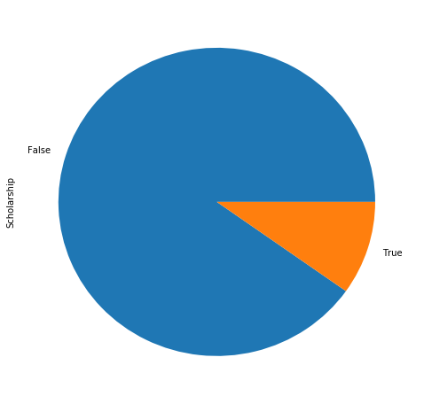

```python
# Graphical representation of patients with scholarship and patients without scholasrship

df_appointments['Scholarship'].value_counts().plot(kind='pie', figsize=(8,8))
```

The plot above shows that 10861 patients had scholarship, while 99665 patients do not have scholarship

```python
# the code shows the total number of people present for their appointments
# 88207 show up for their appointments while 22319 patients did not show up for their appointment

cnt = df_appointments['No_show'].value_counts()
cnt
```

```
No     88207
Yes    22319
Name: No_show, dtype: int64
```

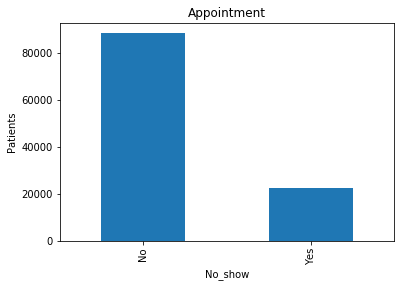

```python
#Grapical representation of patients who did not show up for their appointments and patients that showed up for their appointment

def display_plot(x):
     x.plot(kind = 'bar')
     plt.title("Appointment")
     plt.xlabel("No_show")
     plt.ylabel("Patients")
     return x.all

plt.show(display_plot(cnt))
```

The graph above indicates that 88207 show up for their appointments while 22319 patients did not show up for their appointment

```python
df_appointments.groupby('Scholarship')['No_show'].value_counts()
```

```
Scholarship  No_show
False        No         79924
             Yes        19741
True         No          8283
             Yes         2578
Name: No_show, dtype: int64
```

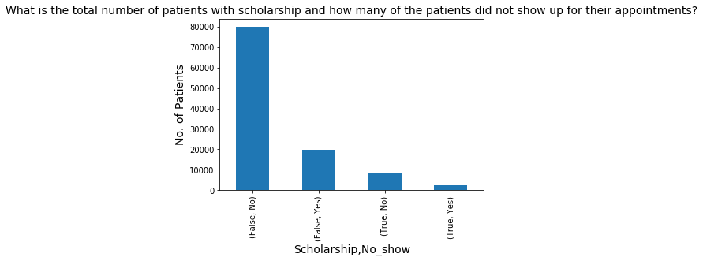

```python
#graphical representation of patients with scholarship that show up for appointments and did not show up for appointment and
#patietns without no scholarship that showed up for appointments and patitent with =out scholarship that did not show up for appointments

patient_showup = df_appointments.groupby('Scholarship')['No_show'].value_counts()


plt.xlabel("Scholarship and No Scholarship appointment show up", fontsize=14)
plt.ylabel("No. of Patients", fontsize=14)
plt.title('What is the total number of patients with scholarship and how many of the patients did not show up for their appointments?', fontsize=14)
patient_showup.plot(kind='bar')
```

The graphical representation above shows that 79924 (80.2%) patients do not have scholarship but showed up for their appointments, 19741(19.8%) patients do not have scholarship and did not show up for their appointments, 8283 (76.3%) patients have scholarship and showed up for their appointments 2578(23.7%) patients have scholarship but did not show up for their appointments

### Research Question 2 - Does gender determine if patients show up for appointments or not?

```python
# Continue to explore the data to address your additional research
#   questions. Add more headers as needed if you have more questions to
#   investigate.
```

```python
#checking the total number of female in the datasets that book appointment

df_appointments.query('Gender == "F"').count()['AppointmentID']
```

```
71839
```

```python
#checking the total number of male in the datasets that book appointment

df_appointments.query('Gender == "M"').count()['AppointmentID']
```

```
38687
```

```python
# Assigning a variable to the patients who did not show up for their appointments

df_noshow = df_appointments[df_appointments['No_show'] == "Yes"]
```

```python
# Calculating number of female that did not show up for their appointment

df_noshow.query('Gender == "F"').count()['AppointmentID']
```

```
14594
```

```python
# Calculating number of female that did not show up for their appointment

df_noshow.query('Gender == "M"').count()['AppointmentID']
```

```
7725
```

[output not shown]

```python
#Calculating the percentage of female that did not show up for their appointment

def no_showpercent(a,b):
   return (a/b)*100

Female_noshow = no_showpercent(14594,71839)
Female_noshow
```

```
20.314870752655242
```

```python
#Calculating the percentage of male that did not show up for their appointment

Male_noshow = no_showpercent(7725,71839)
Male_noshow
```

```
10.75321204359749
```

```
Text(0,0.5,'No_show in %')
```

[figure not shown]

```python
locations = [1,2]
labels = ['Male', 'Female']
heights = [Male_noshow, Female_noshow]
plt.bar(locations, heights, tick_label=labels)
plt.title("Relationship between gender showing up for appointments")
plt.xlabel("Gender")
plt.ylabel("No_show in %")
```

## Conclusions

Based on the findings generated from the research questions, and taking into consideration the limitations, it was found out that

1.Out of the total number of patients which was recorded at 110526 after cleaning of the data, 22319 patients did not show up for their appointments

2.79924 (80.2%) patients do not have scholarship but showed up for their appointments

3.19741(19.8%) patients do not have scholarship and did not show up for their appointments

4.8283 (76.3%) patients have scholarship and showed up for their appointments

5.2578(23.7%) patients have scholarship but did not show up for their appointments

6.It was noted that scholarship does not have positive effects on patients showing up for their appointments

Limitations of the analysis

Correlation between No_show and scholarship was not defined in the analysis The study does not include whether SMS recieved have impact on patients showing up for their appointments

```python
from subprocess import call
call(['python', '-m', 'nbconvert', 'Investigate_a_Dataset.ipynb'])
```

```
0
```